# Building a Linear Regression Model Using Fyntra Customer Data

- #### Avg_Session_Length: Average session of in-store style advice sessions.
- #### Time_on_App: Average time spent on App in minutes
- #### Time_on_Website: Average time spent on Website in minutes
- #### Length_of_Membership: How many years the customer has been a member.
- #### Yearly_Amount_Spent: The output parameter -- Amount Spend in thousand $ in a year

## Importing the main libraries

```python
import pandas as pd
import numpy as np
import matplotlib.pyplot as plt
import seaborn as sns
```

```python
df = pd.read_csv('FyntraCustomerData.csv')
df
```

|  | Email | Address | Avatar | Avg_Session_Length | Time_on_App | Time_on_Website | Length_of_Membership | Yearly_Amount_Spent |
| --- | --- | --- | --- | --- | --- | --- | --- | --- |
| 0 | mstephenson@fernandez.com | 835 Frank Tunnel\nWrightmouth, MI 82180-9605 | Violet | 34.497268 | 12.655651 | 39.577668 | 4.082621 | 587.951054 |
| 1 | hduke@hotmail.com | 4547 Archer Common\nDiazchester, CA 06566-8576 | DarkGreen | 31.926272 | 11.109461 | 37.268959 | 2.664034 | 392.204933 |
| 2 | pallen@yahoo.com | 24645 Valerie Unions Suite 582\nCobbborough, D... | Bisque | 33.000915 | 11.330278 | 37.110597 | 4.104543 | 487.547505 |
| 3 | riverarebecca@gmail.com | 1414 David Throughway\nPort Jason, OH 22070-1220 | SaddleBrown | 34.305557 | 13.717514 | 36.721283 | 3.120179 | 581.852344 |
| 4 | mstephens@davidson-herman.com | 14023 Rodriguez Passage\nPort Jacobville, PR 3... | MediumAquaMarine | 33.330673 | 12.795189 | 37.536653 | 4.446308 | 599.406092 |
| ... | ... | ... | ... | ... | ... | ... | ... | ... |
| 495 | lewisjessica@craig-evans.com | 4483 Jones Motorway Suite 872\nLake Jamiefurt,... | Tan | 33.237660 | 13.566160 | 36.417985 | 3.746573 | 573.847438 |
| 496 | katrina56@gmail.com | 172 Owen Divide Suite 497\nWest Richard, CA 19320 | PaleVioletRed | 34.702529 | 11.695736 | 37.190268 | 3.576526 | 529.049004 |
| 497 | dale88@hotmail.com | 0787 Andrews Ranch Apt. 633\nSouth Chadburgh, ... | Cornsilk | 32.646777 | 11.499409 | 38.332576 | 4.958264 | 551.620146 |
| 498 | cwilson@hotmail.com | 680 Jennifer Lodge Apt. 808\nBrendachester, TX... | Teal | 33.322501 | 12.391423 | 36.840086 | 2.336485 | 456.469510 |
| 499 | hannahwilson@davidson.com | 49791 Rachel Heights Apt. 898\nEast Drewboroug... | DarkMagenta | 33.715981 | 12.418808 | 35.771016 | 2.735160 | 497.778642 |

500 rows × 8 columns

```python
df.info()
```

```
<class 'pandas.core.frame.DataFrame'>
RangeIndex: 500 entries, 0 to 499
Data columns (total 8 columns):
 #   Column                Non-Null Count  Dtype
---  ------                --------------  -----
 0   Email                 500 non-null    object
 1   Address               500 non-null    object
 2   Avatar                500 non-null    object
 3   Avg_Session_Length    500 non-null    float64
 4   Time_on_App           500 non-null    float64
 5   Time_on_Website       500 non-null    float64
 6   Length_of_Membership  500 non-null    float64
 7   Yearly_Amount_Spent   500 non-null    float64
dtypes: float64(5), object(3)
memory usage: 31.4+ KB
```

### No missing values in the dataset

```python
df.describe()
```

|  | Avg_Session_Length | Time_on_App | Time_on_Website | Length_of_Membership | Yearly_Amount_Spent |
| --- | --- | --- | --- | --- | --- |
| count | 500.000000 | 500.000000 | 500.000000 | 500.000000 | 500.000000 |
| mean | 33.053194 | 12.052488 | 37.060445 | 3.533462 | 499.314038 |
| std | 0.992563 | 0.994216 | 1.010489 | 0.999278 | 79.314782 |
| min | 29.532429 | 8.508152 | 33.913847 | 0.269901 | 256.670582 |
| 25% | 32.341822 | 11.388153 | 36.349257 | 2.930450 | 445.038277 |
| 50% | 33.082008 | 11.983231 | 37.069367 | 3.533975 | 498.887875 |
| 75% | 33.711985 | 12.753850 | 37.716432 | 4.126502 | 549.313828 |
| max | 36.139662 | 15.126994 | 40.005182 | 6.922689 | 765.518462 |

## 1. Compute --Use seaborn to create a jointplot to compare the Time on Website and Yearly Amount Spent columns. Is there a correlation?

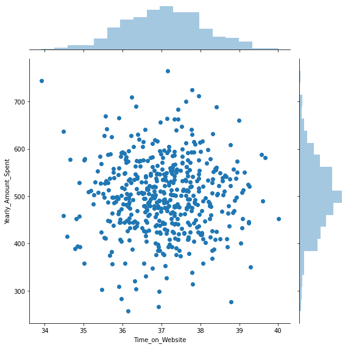

```python
sns.jointplot(x=df.Time_on_Website, y=df.Yearly_Amount_Spent, data=df, height=8)
plt.show()
```

### There does not seem to be any direct correlation between time spent on the website and yearly amount spent.

## 2. Compute –Do the same as above but now with Time on App and Yearly Amount Spent. Is this correlation stronger than 1st One?

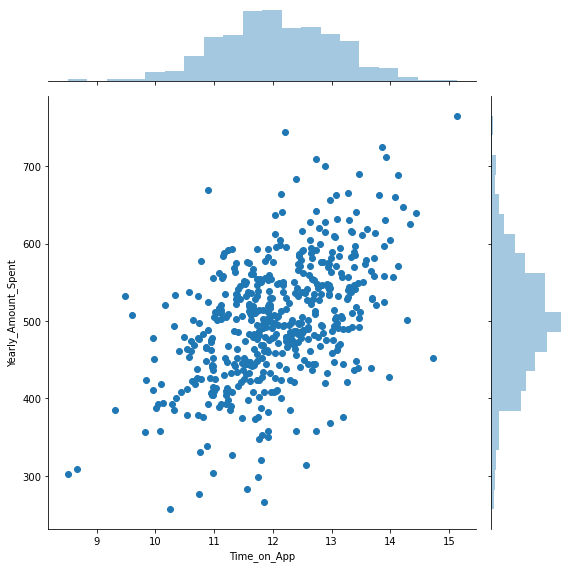

```python
sns.jointplot(x=df.Time_on_App, y=df.Yearly_Amount_Spent, data=df, height=8)
plt.show()
```

### Correlation is a lot stronger with time spent on the app. There is a positive Linear correlation.

## 3. Compute -- Explore types of relationships across the entire data set using pairplot . Based off this plot what looks to be the most correlated feature with Yearly Amount Spent?

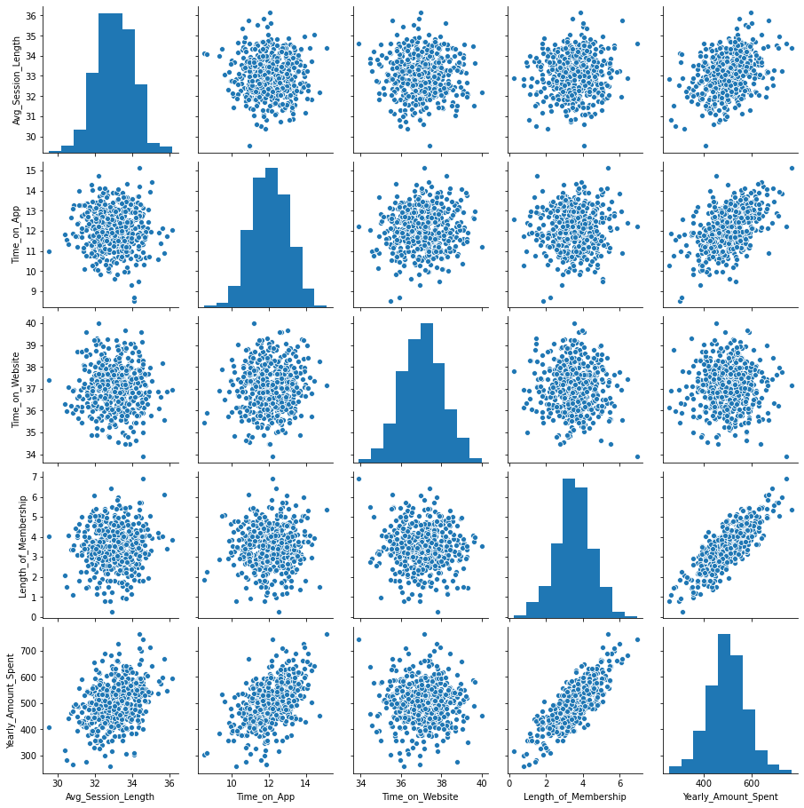

```python
sns.pairplot(data=df)
plt.show()
```

### The most correlated feature with Yearly Amount Spent seems to be the Length of Membership. The longer a customer has had a membership, the greater the brand loyalty and purchasing amount.

## 4.Compute – Create linear model plot of Length of Membership and Yearly Amount Spent. Does the data fit well in linear plot?

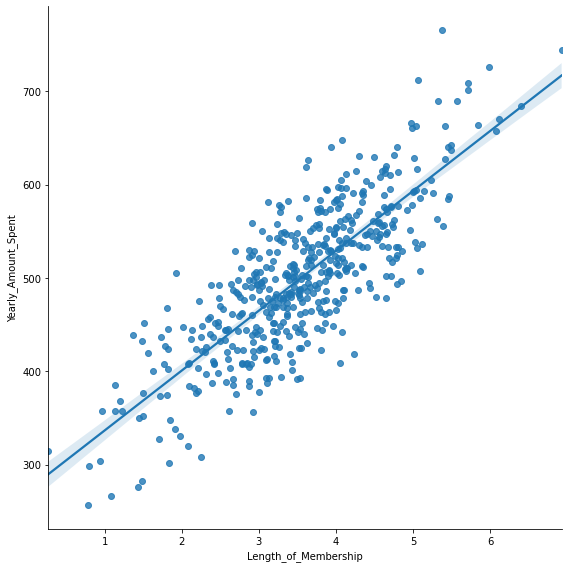

```python
sns.lmplot(x='Length_of_Membership', y='Yearly_Amount_Spent', data=df, height=8)
plt.show()
```

## 5. Compute – Train and Test the data and answer multiple questions -- What is the use of random_state=85?

```python
from sklearn.linear_model import LinearRegression
from sklearn.model_selection import train_test_split
from sklearn.metrics import mean_squared_error
from sklearn.metrics import mean_absolute_error
```

```python
X = df.iloc[:,3:7]
y = df.iloc[:,-1]
```

```python
X_train, X_test, y_train, y_test = train_test_split(X,y,test_size=0.2, random_state=85)
```

### random_state simply sets a seed to the random generator, so that your train-test splits are always deterministic. If you don't set a seed, it is different each time.

```python
lr = LinearRegression()
lr.fit(X_train, y_train)
```

```
LinearRegression()
```

## 6. Compute – Predict the data and do a scatter plot. Check if actual and predicted data match?

## 7. What is the value of Root Mean Squared Error?

```python
y_pred = lr.predict(X_test)
```

```python
print(f"{'-'*30}\ny-intercept: {lr.intercept_}\n{'-'*30}")
for var, coef in zip(X.columns, lr.coef_):
    print(f"Variable: {var}\nCoefficient: {coef}\n{'='*30}")
print(f"Mean Squared Error: {mean_squared_error(y_test, y_pred)}")
print(f"Root Mean Squared Error: {np.sqrt(mean_squared_error(y_test, y_pred))}")
print(f"Mean Absolute Error: {mean_absolute_error(y_test, y_pred)}")
print(f"R Squared (Train): {lr.score(X_train, y_train)}")
print(f"R-Squared (Test): {lr.score(X_test, y_test)}")
```

```
------------------------------
y-intercept: -1071.2205471936836
------------------------------
Variable: Avg_Session_Length
Coefficient: 25.947251632538528
==============================
Variable: Time_on_App
Coefficient: 39.066820644810356
==============================
Variable: Time_on_Website
Coefficient: 0.6825300909027224
==============================
Variable: Length_of_Membership
Coefficient: 61.33469418211988
==============================
Mean Squared Error: 95.03600581432403
Root Mean Squared Error: 9.748641229131577
Mean Absolute Error: 7.637028243772265
R Squared (Train): 0.9848694990595015
R-Squared (Test): 0.9809686791264653
```

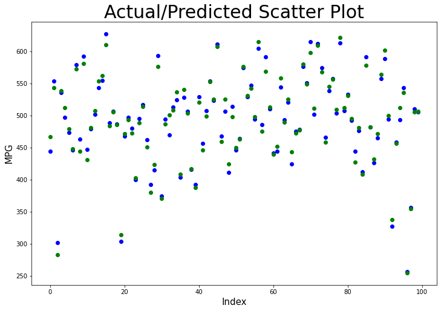

```python
plt.figure(figsize=(12,8))
plt.scatter(y_test.reset_index(drop=True).index, y_test, c='blue', label='Actual')
plt.scatter(pd.Series(y_pred).index, y_pred, c='green', label='Predicted')
plt.title('Actual/Predicted Scatter Plot', fontsize=30)
plt.ylabel('MPG', fontsize=15)
plt.xlabel('Index', fontsize=15)
plt.show()
```

### Actual and Predicted data points are close together, meaning our model did a good job predicting our y variables.